# Homework 1

# Submission Instructions

- Please submit your responses as a nicely formatted notebook (.ipynb) file.
- For questions that require calculations:
  - Show your work (i.e., show the R code you used to answer the question).
  - Make sure all the code you used to answer the question has been run (i.e., displays an output) otherwise you will get a zero for that question.
  - If your *answer* includes many decimal places (e.g., 3.14159265358979), please round it to a reasonable number of decimals for readability (typically 3 to 4).
  - There should be no rounding inside the calculations you do, only round the final result if necessary.
  - For ease of marking, avoid showing the outputs of unnecessary values.
- **Note that one question is kind of a trick question.**

# Question 1

Create a vector with 10,000 values/elements in it (it doesn’t matter what the values are). Without displaying the contents of the vector, write some code that shows it contains 10,000 values/elements.

# Question 2

From the previous question, use R code to determine what the first and last value/element of the vector you made is.

# Question 3

Use R code to create a dataframe that contains information about your top 10 favourite songs. The dataframe should have three columns:

1. ‘Artist’ (the name of the artist/band)
2. ‘Song’ (the name of the song),
3. The name of the album the song appeared on.

Display the dataframe you create.

# Question 4

Use the following variables to answer the next questions. Write R code to answer them.

$x = [1, 34, 463, 386, 44, 444, 173]$

$y = [34, 410, 245, 645, 46, 620, 605]$

## a.

$\sum x$

## b.

$\sum y$

## c.

$\sum x^2$

## d.

$\sum y^2$

## e.

$\sum (x - y)$

## f.

$\sum xy$

## g.

$(\sum x)^2$

## h.

$(\sum y)^2$

## i.

$(\sum (x - y))^2$

## j.

$(\sum x)(\sum y)$

## k.

What value is $x_{_3}$?

## l.

What value is $y_{_4}$?

## m.

Calculate $\frac{\sum x}{n}$ where $n =$ the number of elements in $x$.

## n.

Calculate $\sum\limits_{i=3}^{6} x_i \cdot \sum\limits_{i=2}^{7} y_i$

# Question 5

The data file **swimming.csv** shows the results of Seligman, Nolen-Hecksema, Thornton, and Thornton (1990). Using a questionnaire, they classified their study’s participants, who were members of a university swim team, as *optimists* or *pessimists*. The researchers then asked all the swimmers to swim their best event, but the time that was given to the swimmer was falsified to suggest they did poorly and disappoint them.

Half an hour later they asked them to repeat the event again. The prediction of the study was that, on their second trial pessimists would do worse and optimists would do better.

The dependent variable was a ratio of the two times $\left( \frac{\text{time}_1}{\text{time}_2} \right)$. Thus, a value greater than 1.0 indicates faster times on the second trial.

Without using the function `mean()`, calculate the mean for each group (*optimists* and *pessimists*). Based on the means, does it look as if they were correct?

# Question 6

Describe what happens to the mean for the optimist and pessimist data respectively if each value has 5 added to it?

# Question 7

Describe what happens to the mean for the optimist and pessimist data respectively if each value has 2 multiplied to it?

# Question 8

Sixty-five participants were asked how much sleep they believe they get on average. Fourteen people answered that they generally sleep about six hours; nineteen about seven hours; twelve get around four hours; nine get about three hours; and eleven get about eight hours. Calculate the mean.

**To make your life easier, you might want to read up on weighted means:**

- **https://www.mathsisfun.com/data/weighted-mean.html**

# Question 9

The following dataframe contains the total number of deaths worldwide as a result of earthquakes from 2000 to 2012.

```
##    year deaths
## 1  2000    231
## 2  2001  21357
## 3  2002  11685
## 4  2003  33819
## 5  2004 228802
## 6  2005  88003
## 7  2006   6605
## 8  2007    712
## 9  2008  88011
## 10 2009   1790
## 11 2010 320120
## 12 2011  21953
## 13 2012    768
```

## a.

Recreate the dataframe using R.

## b.

What percentage of deaths occurred before 2001?

## c.

What percentage of deaths occurred from 2003 to 2010 inclusive?

# Question 10

## a.

There are 100 points in the plot below. The first point starts at $[1, 1]$. Re-create this plot.

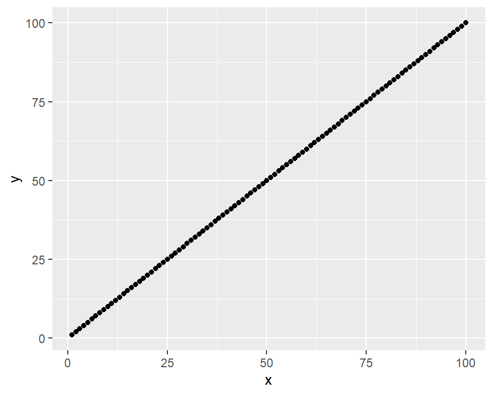

## b.

Re-create the plot again, but this time transform the $x$-axis’ data using a base-5 logarithm ($\log_5$).

## c.

Re-create the plot again, but this time transform the $y$-axis’ data using a base-5 logarithm.

## d.

Re-create the plot one more time and transform both axis’ data with a base-5 logarithm.

# Question 11

## a.

Which three variables would be measured on a nominal scale?

- socioeconomic status
- typing speed
- nationality
- assertiveness
- religious affiliation
- speaking ability
- favourite food
- musical ability
- year of birth
- age

## b.

Which option from the list best illustrates an interval scale?

## c.

Which two variables in the list are most likely to be measured by a ratio scale?

## d.

Can observations on an interval or ratio scale be converted to an ordinal scale (ranks)?

## e.

If an ordinal scale (such as your letter grades in a course) are converted into numbers (e.g., grade point values), what scale of measurement do they become?

## f.

To say that variable $x$ is 25% greater than a variable $y$ illustrates what level of measurement?

## g.

Is the measure “number of books in the library” continuous or discrete?

## h.

Does question g’s measure qualify as a ratio scale?

# Question 12

Assume that some researchers collected data on the variable ‘sex’. They coded 26 females as 1 and 15 males as 0. What is the mean of this variable ‘sex’?

# Question 13

Determine the *probable* skew of the distribution from the following measures of central tendency. Assume the distribution is unimodal.

## a.

$\bar{x} = 16, \text{median} = 10$

## b.

$\bar{x} = 21, \text{median} = 21$

## c.

$\bar{x} = 109, \text{median} = 116$

## d.

$\bar{x} = 73, \text{median} = 84$

## e.

$\bar{x} > \text{median}$

## f.

$\text{mode} > \text{median}$

## g.

$\text{median} > \bar{x}$

## h.

$\bar{x} = \text{median} = \text{mode}$

# Question 14

Using the following histogram to answer a and b:

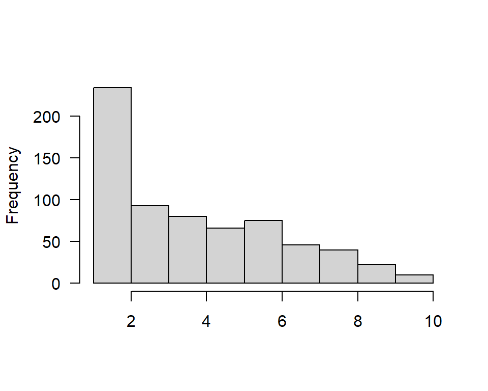

## a.

Describe the skew and modality

## b.

Use [inequalties](https://www.mathsisfun.com/algebra/inequality.html) to describe the the relationship between the mode, median, and mean? e.g., A > B > C

# Question 15

Use the histogram below to answer the next question:

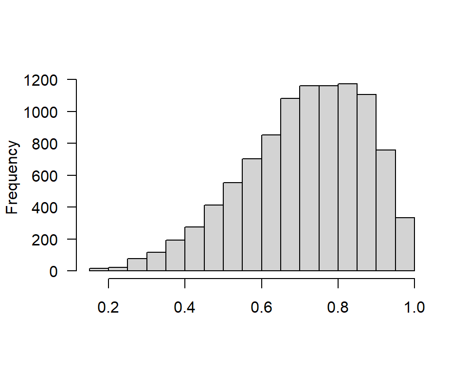

State whether the mean or median would better represent a typical observation in the data and why.

# Question 16

Obtain the Range, Q1, Q2, Q3, and IQR for the sons’ height data (in inches) used in the lecture.

# Question 17

Calculate the first, second, and third quartile of the sons’ height data without using the function `quantile()`.

# Question 18

Find a way to use the `quantile()` function to produce the following percentiles for the sons’ height data used in the lecture: 22%, 27%, 43%, 62%, and 79%.

# Question 19

R has a function called `nrow()`. Use it to determine how many rows are in the Pearson height data. Experiment a bit and explain (in plain English) what makes this function different from the `length()` function.

# Question 20

Using the Pearson height data from the lecture, plot a boxplot of the sons’ heights. Make the boxplot an interesting colour.

# Question 21

Add a column called ‘row’ to the Pearson height data that displays a row number (e.g., 1,2,3,4, and so on…). Once it’s created find a way to move this column so that, going from left to right, it is the first column to be displayed. Print the first 10 rows of the dataframe.

Your final result should look like this …

```
## # A tibble: 10 × 3
##      row Father   Son
##    <int>  <dbl> <dbl>
##  1     1   65    59.8
##  2     2   63.3  63.2
##  3     3   65    63.3
##  4     4   65.8  62.8
##  5     5   61.1  64.3
##  6     6   63    64.2
##  7     7   65.4  64.1
##  8     8   64.7  64
##  9     9   66.1  64.6
## 10    10   67    64
```

# Question 22

Using the Pearson height data, list the values from the sons’ column considered to be outliers according to the boxplot rule.

# Question 23

Plot a histogram of the Sons’ height from the Pearson height data used in the lecture, but do it in centimetres, not inches. Use a different color scheme but keep the binwidth at 1 cm. Label the x-axis “Height of Sons (cm)” and label the y-axis “Frequency”.

# Question 24

Calculate the median and mean of the sons’ height in centimetres.

# Question 25

The *tidyverse* package loads a special operator `%>%` that doesn’t exist in base R. This symbol allows you to “pipe” (i.e., send) things into functions. Run the following snippets of code and explain what the `%>%` operator is doing in each case. Both snippets use the `msleep` dataset we used in the lecture.

## a.

```r
msleep$sleep_total %>% median()
```

## b.

```r
msleep %>% filter(order == "Rodentia")
```

# Question 26

The tidyverse’s `%>%` operator became so popular among R users that, as of R version v4.1.0, a pipe operator (`|>`) was incorporated into the language. Does the base-R pipe, `|>`, work in place of the `%>%` pipe in the two examples above? (Yes/No)

# Question 27

The following code will create a basic dataframe with a single column.

```r
library(tidyverse)
my_nums <- data.frame(Numbers = 1:10000)
```

Recall that a ‘tibble’ is just the tidyverse’s fancier version of a dataframe. We can check if this is a dataframe and tibble respectively by running the code:

```r
is.data.frame(my_nums)
is_tibble(my_nums)
```

Surf the web on how to convert `my_nums` into a tibble and demonstrate that it has been successfully converted.

# Question 28

Calculate $\mu$, $\text{ss}$, $\sigma^2$, and $\sigma$ for the sons’ height data (in inches) used in the lecture. You are NOT allowed to use the function `mean`, `sd()`, or `var()`.